# Data Analysis Report

This analysis sought to answer the following questions:

1. Which breed has the highest viewer engagement?
2. Does the time of the tweet affect the level of interactions?
3. Is there a corellation between dog stage and engagement?

#### 1. What dog has more enggement

Explore breeds with a confidence level over 50%

```python
# breeds over 50%
breed = archive_clean[archive_clean['confidence_lvl'] >= 0.500000]
```

```python
# find breed with the highest favorite and retweet count
breed.groupby('breed').mean().sort_values(by= ['favorites', 'retweets'], ascending= False)
```

| breed | tweet_id | rating_numerator | rating_denominator | favorites | retweets | img_num | confidence_lvl |
| --- | --- | --- | --- | --- | --- | --- | --- |
| saluki | 8.587015e+17 | 13.000000 | 10.0 | 30932.000000 | 6508.000000 | 1.000000 | 0.535929 |
| irish_water_spaniel | 8.453069e+17 | 12.000000 | 10.0 | 25225.000000 | 6039.000000 | 1.000000 | 0.567475 |
| french_bulldog | 7.772229e+17 | 11.227273 | 10.0 | 18099.363636 | 4933.954545 | 1.136364 | 0.847845 |
| afghan_hound | 8.413147e+17 | 13.000000 | 10.0 | 17305.000000 | 5312.000000 | 1.000000 | 0.903712 |
| eskimo_dog | 7.716185e+17 | 11.888889 | 10.0 | 17148.000000 | 7826.555556 | 1.333333 | 0.576585 |
| ... | ... | ... | ... | ... | ... | ... | ... |
| english_springer | 6.736288e+17 | 10.666667 | 10.0 | 804.000000 | 264.000000 | 1.000000 | 0.853234 |
| miniature_schnauzer | 6.686314e+17 | 5.000000 | 10.0 | 763.000000 | 349.000000 | 1.000000 | 0.904549 |
| redbone | 6.685126e+17 | 9.500000 | 10.0 | 653.500000 | 182.500000 | 1.000000 | 0.686523 |
| giant_schnauzer | 6.671713e+17 | 10.000000 | 10.0 | 235.000000 | 97.000000 | 1.000000 | 0.841265 |
| tibetan_terrier | 6.674554e+17 | 7.000000 | 10.0 | 203.000000 | 66.000000 | 1.000000 | 0.676376 |

100 rows × 7 columns

**Observation**

#### 2. **Research Question 2 (Does the time of the tweet affect the level of interaction?)**

```python
# extract hour of the day from timestamp
archive_clean['hour'] = archive_clean['timestamp'].dt.hour
```

```python
# group by hour
tweet_hour = archive_clean.groupby('hour').mean()
tweet_hour
```

| hour | tweet_id | rating_numerator | rating_denominator | favorites | retweets | img_num | confidence_lvl |
| --- | --- | --- | --- | --- | --- | --- | --- |
| 0 | 7.706420e+17 | 11.284444 | 10.000000 | 14047.697778 | 3936.604444 | 1.302222 | 0.559628 |
| 1 | 7.400074e+17 | 12.302128 | 11.404255 | 8668.000000 | 2590.774468 | 1.225532 | 0.558720 |
| 2 | 6.991936e+17 | 10.976608 | 10.707602 | 4807.280702 | 1771.052632 | 1.122807 | 0.530889 |
| 3 | 6.884597e+17 | 10.107914 | 10.000000 | 4099.575540 | 1425.625899 | 1.079137 | 0.522643 |
| 4 | 6.825218e+17 | 13.407895 | 12.894737 | 3393.394737 | 1173.184211 | 1.092105 | 0.515551 |
| 5 | 6.783638e+17 | 17.277778 | 16.111111 | 4029.944444 | 1744.888889 | 1.000000 | 0.515988 |
| 6 | 7.168709e+17 | 12.000000 | 10.000000 | 38129.666667 | 19745.333333 | 1.333333 | 0.611709 |
| 13 | 6.687794e+17 | 10.000000 | 10.000000 | 749.000000 | 409.000000 | 1.000000 | 0.285508 |
| 14 | 7.565892e+17 | 11.500000 | 10.000000 | 6995.250000 | 1897.750000 | 2.000000 | 0.862078 |
| 15 | 7.559731e+17 | 10.688312 | 10.000000 | 11035.233766 | 3221.623377 | 1.246753 | 0.522953 |
| 16 | 7.880848e+17 | 11.582353 | 10.135294 | 14388.100000 | 3809.911765 | 1.247059 | 0.625138 |
| 17 | 7.608462e+17 | 11.861111 | 10.416667 | 9843.583333 | 2766.881944 | 1.215278 | 0.527173 |
| 18 | 7.311805e+17 | 10.731707 | 10.000000 | 11202.463415 | 4352.548780 | 1.207317 | 0.512996 |
| 19 | 7.397792e+17 | 10.823529 | 10.000000 | 9083.250000 | 3077.705882 | 1.338235 | 0.532228 |
| 20 | 7.245160e+17 | 10.500000 | 10.000000 | 8378.241935 | 2870.677419 | 1.209677 | 0.502027 |
| 21 | 7.239683e+17 | 11.762712 | 10.677966 | 6228.016949 | 1903.677966 | 1.118644 | 0.564568 |
| 22 | 7.483805e+17 | 11.290909 | 10.000000 | 8994.272727 | 2847.563636 | 1.400000 | 0.567779 |
| 23 | 7.546894e+17 | 11.656250 | 9.968750 | 9077.552083 | 2690.770833 | 1.260417 | 0.583276 |

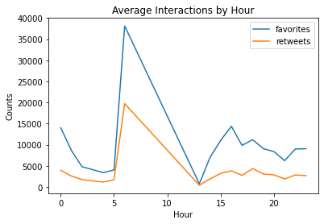

```python
tweet_hour.plot(kind = 'line', y = ['favorites', 'retweets'],xlabel = 'Hour', ylabel = 'Counts', title = 'Average Interactions by Hour')
```

**Observation**

- Tweets within the hour of 6am have the highest favorite and retweet counts
- Tweets within the hour of 1pm have the lowest favorite and retweet counts

#### 3. **Research Question 3 (Is a dog stage associated with more ratings)**

```python
# group data by stage
dog_stage = archive_clean.groupby('stage').mean()
dog_stage
```

| stage | tweet_id | rating_numerator | rating_denominator | favorites | retweets | img_num | confidence_lvl | hour |
| --- | --- | --- | --- | --- | --- | --- | --- | --- |
|  | 7.375862e+17 | 11.510175 | 10.632281 | 8801.985965 | 2621.910877 | 1.202105 | 0.544939 | 9.681404 |
| doggo | 8.007910e+17 | 11.785714 | 10.000000 | 19104.410714 | 6891.625000 | 1.267857 | 0.516533 | 11.428571 |
| doggo, pupper | 7.688683e+17 | 11.800000 | 10.000000 | 15664.200000 | 5482.400000 | 1.200000 | 0.819709 | 7.600000 |
| floofer | 7.665514e+17 | 12.000000 | 10.000000 | 13206.000000 | 4968.714286 | 1.142857 | 0.609204 | 7.857143 |
| pupper | 7.220454e+17 | 10.976471 | 10.000000 | 7551.288235 | 2420.911765 | 1.288235 | 0.583529 | 9.705882 |
| puppo | 8.124018e+17 | 12.000000 | 10.000000 | 22657.181818 | 6958.500000 | 1.454545 | 0.637540 | 12.909091 |

**Observation**

- floofer and puppo have the highest ratings

### Conclusion

1. Saluki breed has more engagement than the other breeds
2. Tweets within the the hour of 6am are likely to have more interactions
3. Floofer and Puppo dog stages are most likely to get more ratings

**Limitations**

1. Authentication issues for a developer account results in download of text file made available by Udacity, containing retweet and favorite counts instead of querying Twitters API.
2. Limitations in statistical knowledge from the developer.

## Analyze

This analysis seeks to answer the following questions:

1. Which breed has the highest viewer engagement?
2. Does the time of the tweet affect the level of interactions?
3. Is there a corellation between dog stage and engagement?